# Book exercises

Author

Daniela Palleschi

# Set options

```r
# set global knit options
knitr::opts_chunk$set(echo = T,
                      eval = T,
                      error = F,
                      warning = F,
                      message = F,
                      cache = T)

# suppress scientific notation
options(scipen=999)

# list of required packages
packages <- c( #"SIN", # this package was removed from the CRAN repository
               "MASS", "dplyr", "tidyr", "purrr", "extraDistr", "ggplot2", "loo", "bridgesampling", "brms", "bayesplot", "tictoc", "hypr", "bcogsci", "papaja", "grid", "kableExtra", "gridExtra", "lme4", "cowplot", "pdftools", "cmdstanr", "rootSolve", "rstan"
  )

# NB: if you haven't already installed bcogsci through devtools, it won't be loaded
## Now load or install & load all
package.check <- lapply(
  packages,
  FUN = function(x) {
    if (!require(x, character.only = TRUE)) {
      install.packages(x, dependencies = TRUE)
      library(x, character.only = TRUE)
    }
  }
)

# this is also required, taken from the textbook

## Save compiled models:
rstan_options(auto_write = FALSE)
## Parallelize the chains using all the cores:
options(mc.cores = parallel::detectCores())
# To solve some conflicts between packages
select <- dplyr::select
extract <- rstan::extract
```

# 1 Chapter 1 - Introduction

## Exercise 1.1 Practice using the pnorm function - Part 1

Given a normal distribution with mean 500 and standard deviation 100, use the pnorm function to calculate the probability of obtaining values between 200 and 800 from this distribution.

```r
pnorm(800, 500, 100) - pnorm(200, 500, 100)
```

```
[1] 0.9973002
```

## Exercise 1.2 Practice using the pnorm function - Part 2

Calculate the following probabilities. Given a normal distribution with mean 800 and standard deviation 150, what is the probability of obtaining:

- a score of 700 or less
- a score of 900 or more
- a score of 800 or more

```r
# 700 or more
pnorm(700,800,150)
```

```
[1] 0.2524925
```

```r
# 900, 800 or more
pnorm(c(900,800), 800,150, lower.tail=F)
```

```
[1] 0.2524925 0.5000000
```

## Exercise 1.3 Practice using the pnorm function - Part 3

Given a normal distribution with mean 600 and standard deviation 200, what is the probability of obtaining:

- a score of 550 or less.
- a score between 300 and 800.
- a score of 900 or more.

```r
# 550 or less
pnorm(q = 550,
      m = 600, sd = 200)
```

```
[1] 0.4012937
```

```r
# 300-800
pnorm(q = 800,
      m = 600, sd = 200) - pnorm(q = 300, m = 600, sd = 200)
```

```
[1] 0.7745375
```

```r
# 900 or more
pnorm(q = 900,
      m = 600, sd = 200, lower.tail=F)
```

```
[1] 0.0668072
```

## Exercise 1.4 Practice using the qnorm function - Part 1

Consider a normal distribution with mean 1 and standard deviation 1. Compute the lower and upper boundaries such that:

- the area (the probability) to the left of the lower boundary is 0.10.
- the area (the probability) to the left of the upper boundary is 0.90.

```r
# lower bound is .1
qnorm(p = .1,
      mean = 1, sd = 1)
```

```
[1] -0.2815516
```

```r
# lower bound is .9
qnorm(p = .9,
      mean = 1, sd = 1)
```

```
[1] 2.281552
```

## Exercise 1.5 Practice using the qnorm function - Part 2

Given a normal distribution with mean 650 and standard deviation 125. There exist two quantiles, the lower quantile q1 and the upper quantile q2, that are equidistant from the mean 650, such that the area under the curve of the normal between q1 and q2 is 80%. Find q1 and q2.

```r
q1 <- qnorm(p =.1,
            mean = 650, sd = 125)
q2 <- qnorm(p =.9,
            mean = 650, sd = 125)
q1; q2
```

```
[1] 489.8061
```

```
[1] 810.1939
```

```r
# check this is right
pnorm(q = q2,
      m = 650, sd = 125) - pnorm(q = q1, m = 650, sd = 125)
```

```
[1] 0.8
```

## Exercise 1.6 Practice getting summaries from samples - Part 1

Given data that is generated as follows:

```r
data_gen1 <- rnorm(1000, 300, 200)
```

Calculate the mean, variance, and the lower quantile q1 and the upper quantile q2, that are equidistant and such that the range of probability between them is 80%.

```r
mean <- mean(data_gen1)
sd <- sd(data_gen1)

q1 <- qnorm(.1,
            mean,sd)
q2 <- qnorm(.9,
            mean,sd)
q1; q2
```

```
[1] 39.81337
```

```
[1] 558.2104
```

```r
# check
pnorm(q2,mean,sd) - pnorm(q1,mean,sd)
```

```
[1] 0.8
```

## Exercise 1.7 Practice getting summaries from samples - Part 2.

This time we generate the data with a truncated normal distribution from the package extraDistr. The details of this distribution will be discussed later in section 4.1 and in the Box 4.1, but for now we can treat it as an unknown generative process:

```r
data_gen1 <- extraDistr::rtnorm(1000, 300, 200, a = 0)
```

Calculate the mean, variance, and the lower quantile q1 and the upper quantile q2, that are equidistant and such that the range of probability between them is 80%.

```r
mean <- mean(data_gen1)
sd <- sd(data_gen1)

q1 <- qnorm(.1,
            mean,sd)
q2 <- qnorm(.9,
            mean,sd)
q1; q2
```

```
[1] 96.66336
```

```
[1] 573.8571
```

```r
# check
pnorm(q2,mean,sd) - pnorm(q1,mean,sd)
```

```
[1] 0.8
```

## Exercise 1.8 Practice with a variance-covariance matrix for a bivariate distribution.

```r
# generate simulated bivariate data

## define two RVs

## define a VarCorr matrix, where rho = .6, variance
Sigma <- matrix(c(
  100^2, 100 * 50 * .4,
  100 * 50 * .4, 100^2
  ),
  byrow = F, ncol = 2
  )

## generate data
u <- as.data.frame(MASS::mvrnorm(n = 100, mu = c(600,400), Sigma = Sigma))
head(u, n=3)
```

```
        V1       V2
1 493.5843 306.1746
2 576.0776 394.0224
3 577.3254 450.6876
```

Plot the simulated data such that the relationship between the random variables X and Y is clear.

Generate two sets of new data (100 pairs of data points each) with correlation −0.4 and 0, and plot these alongside the plot for the data with correlation 0.4.

```r
# generate simulated bivariate data
rho <- -.4
## define a VarCorr matrix, where rho = 0, variance
Sigma <- matrix(c(
  100^2, 100 * 50 * rho,
  100 * 50 * rho, 100^2
  ),
  byrow = F, ncol = 2
  )

## generate data
u4 <- as.data.frame(MASS::mvrnorm(n = 100, mu = c(600,400), Sigma = Sigma))

# generate simulated bivariate data
rho <- 0
## define a VarCorr matrix, where rho = 0, variance
Sigma <- matrix(c(
  100^2, 100 * 50 * rho,
  100 * 50 * rho, 100^2
  ),
  byrow = F, ncol = 2
  )

## generate data
u0 <- as.data.frame(MASS::mvrnorm(n = 100, mu = c(600,400), Sigma = Sigma))
```

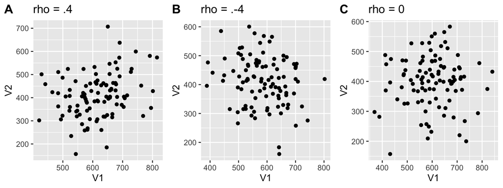

```r
ggpubr::ggarrange(
  ggplot2::ggplot(u, aes(x = V1, y = V2)) +
    labs(title = "rho = .4") +
    geom_point(),
  ggplot2::ggplot(u4, aes(x = V1, y = V2)) +
    labs(title ="rho = .-4") +
    geom_point(),
  ggplot2::ggplot(u0, aes(x = V1, y = V2)) +
    labs(title ="rho = 0") +
    geom_point(),
  nrow = 1, labels = c("A", "B", "C")
)
```

# 2 Chapter 2 - Intro to Bayesian data analysis

#### 2.3 Conjugate forms 2

Suppose you have $n$ independent and identically distributed data points from the Geometric distribution, which has the likelihood function

$$\begin{equation}
f(x|\theta)=\theta(1-\theta)^{\sum_{i=1}^n x_i}
\end{equation}$$

where the data points $x$ can have values 0,1,2,. Let the prior on $\theta$ be $Beta(a,b)$, a beta distribution with parameters a,b. The posterior distribution is a beta distribution with parameters a* and b*. Determine these parameters in terms of $a, b,$ and $\sum_{i=1}^n x_i$.

My work:

- prior is $Beta(a,b)$
- likelihood is $\theta(1-\theta)\sum_{i=1}^n x_i$
- posterior up to proportionality is$[\theta^{a-1}(1-\theta)^{b-1}][\theta(1-\theta)\sum_{i=1}^n x_i$
- sum up the exponentials on either side (and if there’s no exponential then add a +1 cause every number is to the power of 1): $\theta^{a + 1 - 1}(1-\theta)^{b + \sum_{i=1}^n x_i - 1}$
- and cancel out the $^{-1}$: $\theta^{a + 1}(1-\theta)^{b + \sum_{i=1}^n x_i}$

# 3 Chapter 3